# Tree structure

Klaus Schliep

2019-10-27

## Concepts today

- How is a phylogenetic tree stored in R?
- How can we traverse a tree to see and manipulate nodes and branches?
- What are some major packages and key functions in the R computing environment?
- Beyond the tree: What are some important packages that implement comparative methods, biogeography, and visualization?

## A brief history of phylogenetics in R

1993: first release of R

1996: Ihaka & Gentleman, J. Comput. Graph. Statist., 5: 299–314

2000: R 1.0.0

2001: start the development of ape

2002: first release of ape

2008: first release of phangorn

2019: 260 packages depending on ape on CRAN, 16 on BioConductor (and 100’s elsewhere: R-Forge, GitHub, . . .)

## Getting help

So many functions, but how to find/remember them?

- write scripts (and maintain them!)
- help.start()
- ?… (or help(“…”))
- apropos(“…”)
- use TAB-completion (or a “cool” editor)

Operators are also functions:

```r
`+` # or get("+")
## function (e1, e2)  .Primitive("+")
`+`(1, 2)
```

```
## [1] 3
```

Find generic functions for a class

Common generic functions are print, plot, c, summary, anova, [, …

```r
library(ape)
methods(class="phylo")
```

```
##  [1] +                    addConfidences       all.equal
##  [4] as.evonet            as.hclust            as.matching
##  [7] as.networx           as.splits            c
## [10] coalescent.intervals cophenetic           degree
## [13] di2multi             drop.tip             identify
## [16] is.binary            is.rooted            is.ultrametric
## [19] keep.tip             makeLabel            midpoint
## [22] multi2di             Nedge                Nnode
## [25] Ntip                 plot                 print
## [28] reorder              root                 simSeq
## [31] skyline              summary              unroot
## [34] updateLabel          vcv
## see '?methods' for accessing help and source code
```

Run all examples of the help files!

```r
example(plot.phylo)
```

However examples in (CRAN) R packages are not allowed to run longer than 5 seconds. So for inference this results frequently in toy examples. You need to change to higher number of bootstrap iterations, change stop criterion for optimisation et cetera.

Many packages on CRAN and all on Bioconductor come with vignettes.

```r
vignette()
vignette(package="phangorn")
vignette("Trees", package="phangorn")
```

And there is google and stackoverflow.

## The `phylo` class

The `phylo` class is a tree structure in `ape` are the standard for storing phylogenetic in R. It is also used in more than 260 packages on CRAN.

This class represents phylogenetic trees and networks; (internal) nodes are of degree ≥ 2; the tips (terminal nodes) are of degree 1. The tip labels may be replicated (or can even missing). Idem for the node labels (which are optional).

## Structure of phylo objects

An object of class `phylo` is a list containing at least the following objects:

1. An *integer* matrix named edge with two columns and as many rows as there are edges in the tree.
2. A *character* vector named `tip.label`, can be ““.
3. An *integer* `Nnode` with the number of internal nodes.
4. A class attribute `phylo`.

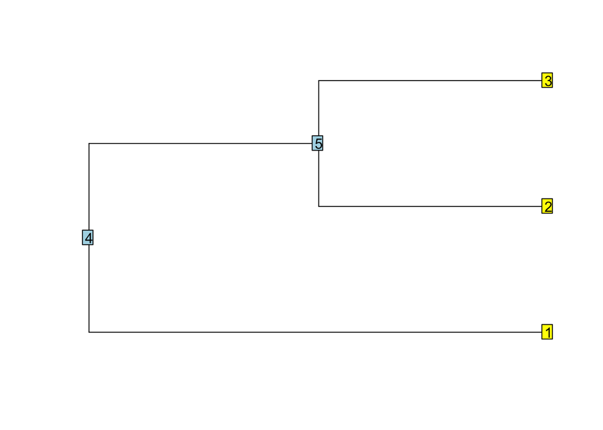

```r
library(ape)
tree <- read.tree(text = "(,(,));")
plot(tree)
nodelabels()
tiplabels()
```

```r
str(tree)
```

```
## List of 3
##  $ edge     : int [1:4, 1:2] 4 4 5 5 1 5 2 3
##  $ Nnode    : int 2
##  $ tip.label: chr [1:3] "" "" ""
##  - attr(*, "class")= chr "phylo"
##  - attr(*, "order")= chr "cladewise"
```

The storage mode is important. Saving a vector of integers saves memory in comparison to vector of doubles. Also objects of class `phylo` often in C-Code so you need to take care of this.

Also comparing doubles is dangerous:

```r
x <- 3
y <- sqrt(3)^2
x==y
```

```
## [1] FALSE
```

In the edge matrix each edge (branch) is coded by the nodes it connects.

```r
tree$edge
```

```
##      [,1] [,2]
## [1,]    4    1
## [2,]    4    5
## [3,]    5    2
## [4,]    5    3
```

Tips (terminal nodes, leaves, labels, …) are numbered from 1 to `n`, where `n` is the number of tips. The root is numbered `n+1`. The ancestral node (closer to the root) is always on the lefthand column.

Some important properties and observations: * the first column only contains values greater than `n`. * all nodes, but the root, appear exactly once in the second column. * in a strictly bifurcating tree, all nodes greater then `n` appear twice and the root node `n+1`, in case of ‘twice’ for rooted and `trice` for unrooted trees.

So we can start and construct a minimal tree ourselves:

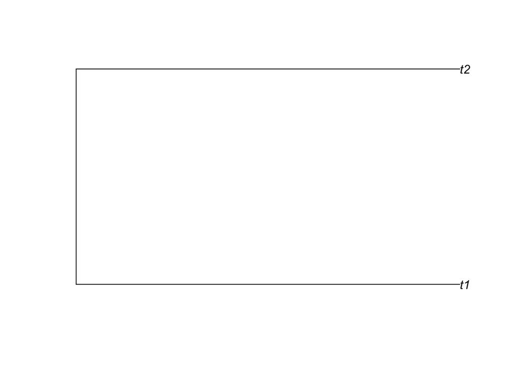

```r
library(ape)
simple_tree <- structure(list(edge = matrix(c(3L, 3L, 1L, 2L), 2, 2),
                        tip.label = c("t1", "t2"), Nnode = 1L), class = "phylo")
plot(simple_tree)
```

A `phylo` object always contains an `edge`, `tip.label` and `Nnode`. Often a phylo object contains some of the following elements:

1. a *numeric* vector `edge.length`. The length of the vector is number of rows of the `edge` matrix and the order corresponds to the rows in `edge`.
2. a *character* vector `node.labels` of length `Nnode`. The node labels are labeled from `n+1` to `n+Nnode`
3. A single *numeric* root.edge providing the edge length at the root.

Additionally most `phylo` objects have an attribute `order`, which can be either “cladewise”, “postorder” or “pruningwise”.

## Tree traversal

Tree traversal in ape is implemented iterative in contrast to the recursive implementation in most other phylogenetic programs.

### Preorder tree traversal

*Preorder tree traversal* is travelling through the tree from the root to the tips visiting always the all nodes the right subtree before visiting the right subtree.

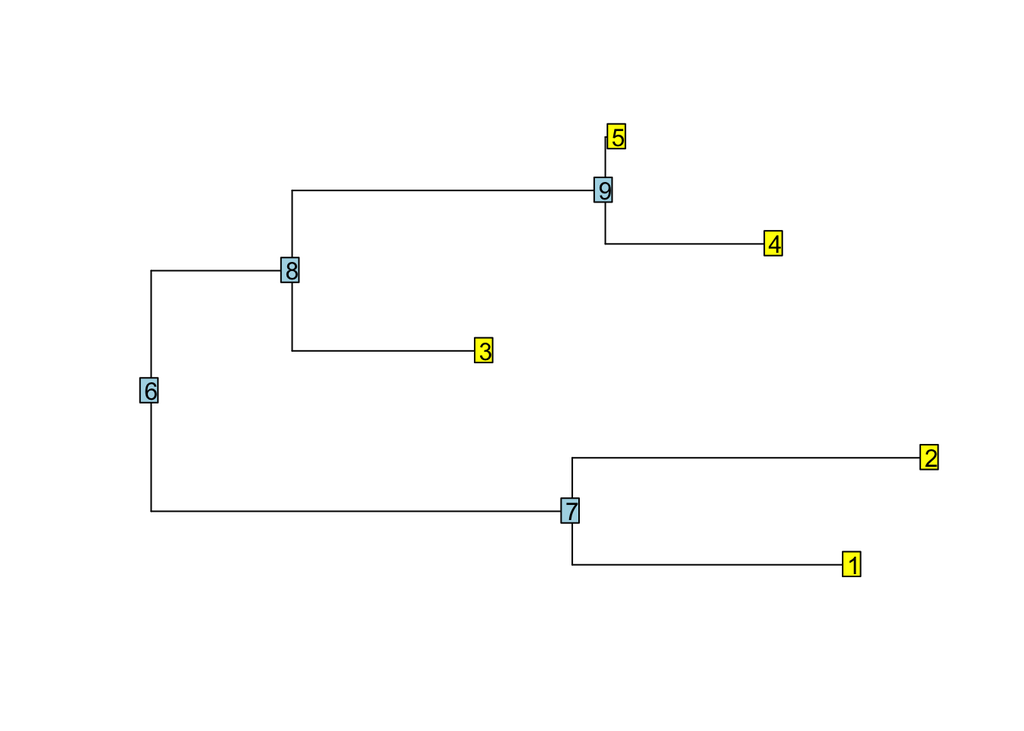

```r
tree <- rtree(5)
plot(tree, show.tip.label = FALSE)
nodelabels()
tiplabels()
```

```r
reorder(tree, "cladewise")$edge
```

```
##      [,1] [,2]
## [1,]    6    7
## [2,]    7    1
## [3,]    7    2
## [4,]    6    8
## [5,]    8    3
## [6,]    8    9
## [7,]    9    4
## [8,]    9    5
```

### Postorder tree traversal

*Postorder tree traversal* travels through the tree from the tips through the root. All the descendent nodes need to be visited before the ancestral node.

```r
reorder(tree, "postorder")$edge
```

```
##      [,1] [,2]
## [1,]    9    4
## [2,]    9    5
## [3,]    8    3
## [4,]    8    9
## [5,]    7    1
## [6,]    7    2
## [7,]    6    7
## [8,]    6    8
```

Defining the order of the traversal of the tree this way allows to iterate just through the tree. Reorder not only changes the order of the `edge` matrix, but also of the `edge.length` if it exists.

###Excercise 1: Write a function which counts how many descendants each node has. The output should look like:

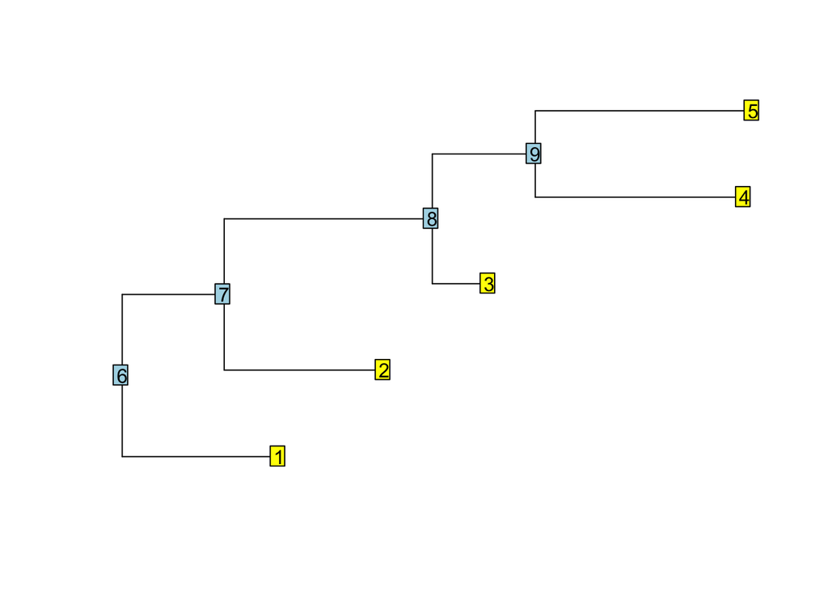

```r
set.seed(42)
tree <- rtree(5)

plot(tree, show.tip.label = FALSE)
nodelabels()
tiplabels()
```

```r
nr_desc(tree)
```

```
## [1] 1 1 1 1 1 5 4 3 2
```

My solutions

```r
library(phangorn)
nr_desc_cheat <- function(x){
  lengths(Descendants(x, 1:max(x$edge)))
}


nr_desc <-  function(x){
    x <- reorder(x, "postorder")
    res <- numeric(max(x$edge))
    res[1:Ntip(x)] = 1L
    for(i in 1:nrow(x$edge)){
        tmp = x$edge[i,1]
        res[tmp] =  res[tmp] + res[x$edge[i,2] ]
    }
    res
}
```

###Excercise 2: Write a function which computes the distance from each node to the root.

```r
tree$edge.length[] <- 1
root_to_tip(tree)
```

```
## [1] 1 2 3 4 4 0 1 2 3
```

My solution:

```r
root_to_tip <-  function(x){
    x <- reorder(x)
    res <- numeric(max(x$edge))
    for(i in 1:nrow(x$edge)){
        pa <- x$edge[i,1]
        ch <- x$edge[i,2]
        res[ch] =  res[pa] + x$edge.length[i]
    }
    res
}
```

## The ‘multiPhylo’ class

An object of class ‘multiPhylo’ is a list of of several trees each of class ‘phylo’. If all trees share the same tip labels, as in bootstrap samples or from MCMC analyses, trees can be saved in a memory efficient way storing the labels only once in an attribute *TipLabel*.

```r
trees <- rmtree(1000, 100)
trees
## 1000 phylogenetic trees
attr(trees, "TipLabel")
## NULL
```

```r
trees_compact <- .compressTipLabel(trees)
attr(trees_compact, "TipLabel")
```

```
##   [1] "t92"  "t69"  "t100" "t2"   "t82"  "t24"  "t18"  "t99"  "t55"  "t40"
##  [11] "t21"  "t57"  "t42"  "t94"  "t13"  "t53"  "t54"  "t83"  "t32"  "t80"
##  [21] "t60"  "t29"  "t73"  "t43"  "t58"  "t72"  "t79"  "t98"  "t38"  "t1"
##  [31] "t86"  "t5"   "t78"  "t16"  "t77"  "t88"  "t65"  "t56"  "t33"  "t59"
##  [41] "t89"  "t74"  "t25"  "t51"  "t96"  "t17"  "t46"  "t14"  "t47"  "t6"
##  [51] "t52"  "t66"  "t37"  "t67"  "t31"  "t34"  "t30"  "t63"  "t81"  "t22"
##  [61] "t75"  "t84"  "t64"  "t20"  "t15"  "t45"  "t23"  "t12"  "t49"  "t26"
##  [71] "t9"   "t71"  "t97"  "t95"  "t27"  "t28"  "t11"  "t85"  "t76"  "t41"
##  [81] "t10"  "t93"  "t48"  "t68"  "t61"  "t19"  "t3"   "t62"  "t87"  "t50"
##  [91] "t36"  "t35"  "t91"  "t90"  "t70"  "t44"  "t4"   "t7"   "t8"   "t39"
```

```r
object.size(trees) / object.size(trees_compact)
## 2.5 bytes
```

Switching between the two representations can be done via ‘.compressTipLabel’ and ‘.uncompressTipLabel’.

## Importing and exporting trees and networks

Package `ape` and `phangorn` contains functions to import trees and splits networks:

- `read.tree` Newick files
- `read.nexus` NEXUS files (only trees)
- `read.evonet` networks in extended Newick format

and

- `write.tree` Newick (one or several trees)
- `write.nexus` NEXUS (one or several trees with or without translate block)
- `write.evonet` extended Newick (.nhx)
- `read.networx` phylogenetic splits networks in nexus format (e.g. Splitstree)

### Example:

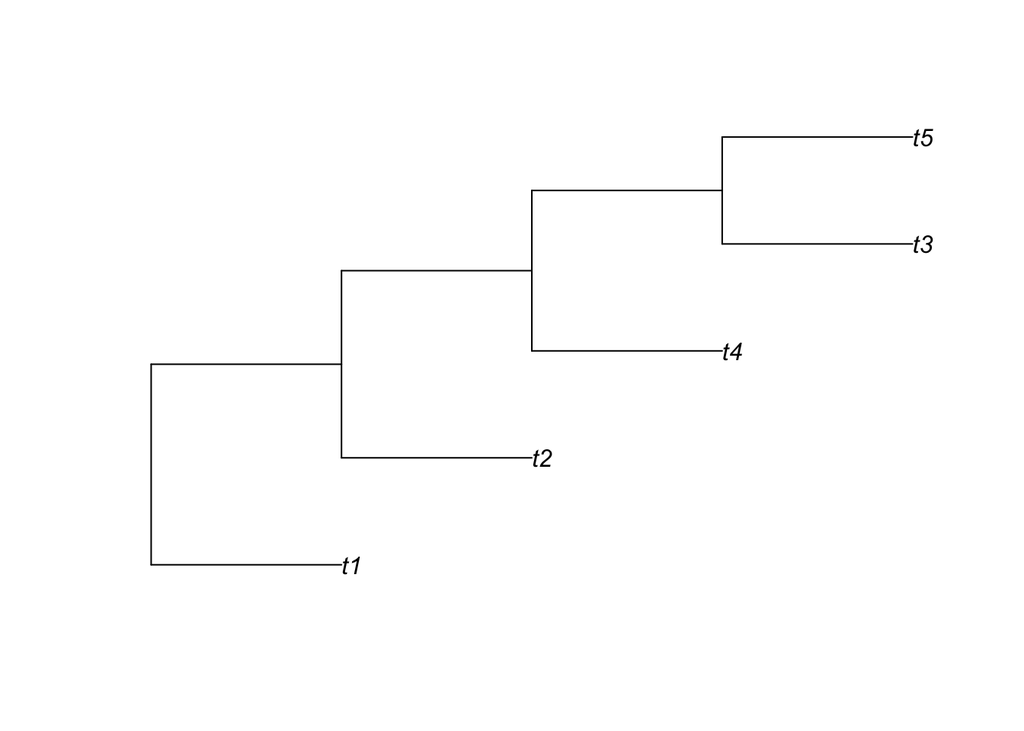

```r
write.tree(tree, "example_tree.nex")
tree_read <- read.tree(file = "example_tree.nex")
plot(tree_read)
```

Any R object(s) can be saved on disk: this is much better if these data are used only in R. (*Faster to read/write, smaller files, and no loss of numerical accuracy.) Several objects:

- `save(X, a, y, file = "X.rda")` several objects with their names
- `load("X.rda")` $\rightarrow$ restores object names (i.e., possibly deletes previous X, a, y in the workspace) A single object:
- `saveRDS(X, file = "X.rds")`
- `Y <- readRDS("X.rds")` $\rightarrow$ the name of the object can be changed

## Functions for `phylo` objects

Before you write a function look what’s already out there.

### Some convenience functions

There are several convenience functions to achieve common tasks:

| Operation | High level | Low level |
| --- | --- | --- |
| How many tips? | Ntip(tr) | length(tr$tip.label) |
| How many node? | Nnode(tr) | tr$Nnode |
| How many edges? | Nedge(tr) | nrow(tr$edge) |
| What are the ancestor of x | Ancestors(tr, x, “parent”) | tr$edge[tr$edge[,2]==x , 1] |
| What are the descendants of x | Descendants(tr, x, “children”) | tr$edge[tr$edge[,1]==x , 2] |

Ntip, Nnode, Nedge are generic and work on `phylo` and `multiPhylo` objects. `Ancestors` and `Descendants` are vectorized , i.e. argument node can be a vector.

## Some useful functions to modify trees

`root(phy, outgroup, ...)`, `unroot(phy)`, `midpoint(tree)`, `drop.tip(phy, tip, ...)`, `keep.tip(phy, tip)`, `extract.clade(phy, node, ...)`, `bind.tree(x, y, ...)`, `c(...)`, `multi2di(phy, random = TRUE)`, `di2multi(phy, tol = 1e-8)`, `rotate(phy, node)`, `rotateConstr(phy, X)`, `reorder(phy, order = "cladewise")`

Some of the above functions have the option interactive (FALSE by default) and many are generic.

And some functions to explore the Baumraum (tree space) `nni`, `rNNI`, `rSPR`, `allTrees`.